# yli130_4

Yanxi Li

10/28/2020

### K means clustering Assignment

### Data Preparation

At this part, we plan to first view some basic information related to the raw data and remove the missing measurements from the data set. But we found the number of raw data row is 1302, after remove the missing data, it only left with 471 rows with means there are many data missing.

Since we know that the larger amount of data is better because it can have a better estimate of the data mean & SD, we plan to normalize the data first and then remove the missing ones.

We only normalize the numerical data(continuous measurements), make sure to change others categorical measurements to the appropriate formats.

```r
# import the data
data <- read.csv("C:/Users/yanxi/OneDrive/Desktop/Machine Learning Assignment/Assignment#4/Universities.csv")
# preview the data
head(data, 3)
```

```
##                        College.Name State Public..1...Private..2.
## 1         Alaska Pacific University    AK                       2
## 2 University of Alaska at Fairbanks    AK                       1
## 3    University of Alaska Southeast    AK                       1
##   X..appli..rec.d X..appl..accepted X..new.stud..enrolled
## 1             193               146                    55
## 2            1852              1427                   928
## 3             146               117                    89
##   X..new.stud..from.top.10. X..new.stud..from.top.25. X..FT.undergrad
## 1                        16                        44             249
## 2                        NA                        NA            3885
## 3                         4                        24             492
##   X..PT.undergrad in.state.tuition out.of.state.tuition room board add..fees
## 1             869             7560                 7560 1620  2500       130
## 2            4519             1742                 5226 1800  1790       155
## 3            1849             1742                 5226 2514  2250        34
##   estim..book.costs estim..personal.. X..fac..w.PHD stud..fac..ratio
## 1               800              1500            76             11.9
## 2               650              2304            67             10.0
## 3               500              1162            39              9.5
##   Graduation.rate
## 1              15
## 2              NA
## 3              39
```

```r
# rows number of the raw data
nrow(data)
```

```
## [1] 1302
```

```r
# check the data structure
str(data)
```

```
## 'data.frame':    1302 obs. of  20 variables:
##  $ College.Name             : chr  "Alaska Pacific University" "University of Alaska at Fairbanks" "University of Alaska Southeast" "University of Alaska at Anchorage" ...
##  $ State                    : chr  "AK" "AK" "AK" "AK" ...
##  $ Public..1...Private..2.  : int  2 1 1 1 1 2 1 1 1 2 ...
##  $ X..appli..rec.d          : int  193 1852 146 2065 2817 345 1351 4639 7548 805 ...
##  $ X..appl..accepted        : int  146 1427 117 1598 1920 320 892 3272 6791 588 ...
##  $ X..new.stud..enrolled    : int  55 928 89 1162 984 179 570 1278 3070 287 ...
##  $ X..new.stud..from.top.10.: int  16 NA 4 NA NA NA 18 NA 25 67 ...
##  $ X..new.stud..from.top.25.: int  44 NA 24 NA NA 27 78 NA 57 88 ...
##  $ X..FT.undergrad          : int  249 3885 492 6209 3958 1367 2385 4051 16262 1376 ...
##  $ X..PT.undergrad          : int  869 4519 1849 10537 305 578 331 405 1716 207 ...
##  $ in.state.tuition         : int  7560 1742 1742 1742 1700 5600 2220 1500 2100 11660 ...
##  $ out.of.state.tuition     : int  7560 5226 5226 5226 3400 5600 4440 3000 6300 11660 ...
##  $ room                     : int  1620 1800 2514 2600 1108 1550 NA 1960 NA 2050 ...
##  $ board                    : int  2500 1790 2250 2520 1442 1700 NA NA NA 2430 ...
##  $ add..fees                : int  130 155 34 114 155 300 124 84 NA 120 ...
##  $ estim..book.costs        : int  800 650 500 580 500 350 300 500 600 400 ...
##  $ estim..personal..        : int  1500 2304 1162 1260 850 NA 600 NA 1908 900 ...
##  $ X..fac..w.PHD            : int  76 67 39 48 53 52 72 48 85 74 ...
##  $ stud..fac..ratio         : num  11.9 10 9.5 13.7 14.3 32.8 18.9 18.7 16.7 14 ...
##  $ Graduation.rate          : int  15 NA 39 NA 40 55 51 15 69 72 ...
```

```r
# change public/private into factor
data$Public..1...Private..2. <- factor(data$Public..1...Private..2.)
# view how many data is missing
colMeans(is.na(data))
```

```
##              College.Name                     State   Public..1...Private..2.
##               0.000000000               0.000000000               0.000000000
##           X..appli..rec.d         X..appl..accepted     X..new.stud..enrolled
##               0.007680492               0.008448541               0.003840246
## X..new.stud..from.top.10. X..new.stud..from.top.25.           X..FT.undergrad
##               0.180491551               0.155145929               0.002304147
##           X..PT.undergrad          in.state.tuition      out.of.state.tuition
##               0.024577573               0.023041475               0.015360983
##                      room                     board                 add..fees
##               0.246543779               0.382488479               0.210445469
##         estim..book.costs         estim..personal..             X..fac..w.PHD
##               0.036866359               0.139016897               0.024577573
##          stud..fac..ratio           Graduation.rate
##               0.001536098               0.075268817
```

```r
# select the categorical measurements
categori_data <- data[,c(1,2,3)]
# exclude the first 3 categorical measurements to scale
data_norm <- scale(data[,-c(1,2,3)])
# change the nor data into data frame
data_norm <- as.data.frame(data_norm)
# combine the categorical measurements and the normalized continuous measurements together for the following questions
data_norm_with_category <- cbind(categori_data, data_norm)
# preview the combine data frame
head(data_norm_with_category, 3)
```

```
##                        College.Name State Public..1...Private..2.
## 1         Alaska Pacific University    AK                       2
## 2 University of Alaska at Fairbanks    AK                       1
## 3    University of Alaska Southeast    AK                       1
##   X..appli..rec.d X..appl..accepted X..new.stud..enrolled
## 1      -0.7225059        -0.7662308            -0.8183340
## 2      -0.2541231        -0.1971166             0.1685769
## 3      -0.7357753        -0.7791147            -0.7798976
##   X..new.stud..from.top.10. X..new.stud..from.top.25. X..FT.undergrad
## 1                -0.5281592                 -0.399879     -0.75770745
## 2                        NA                        NA      0.04231932
## 3                -1.1834451                 -1.357673     -0.70424032
##   X..PT.undergrad in.state.tuition out.of.state.tuition         room      board
## 1      -0.1270939       -0.0630636           -0.4116519 -0.777418588  0.6634249
## 2       2.0556556       -1.1509138           -0.9712607 -0.621010666 -0.4095007
## 3       0.4589594       -1.1509138           -0.9712607 -0.000592575  0.2856342
##    add..fees estim..book.costs estim..personal.. X..fac..w.PHD stud..fac..ratio
## 1 -0.5582110         1.4939890         0.1549998    0.41257065       -0.5704863
## 2 -0.5049492         0.5976928         1.2806595   -0.09232041       -0.9368291
## 3 -0.7627364        -0.2986034        -0.3182253   -1.66309261       -1.0332351
##   Graduation.rate
## 1       -2.403789
## 2              NA
## 3       -1.133212
```

```r
# Remove the missing measurements from the continuous measurements
Rem_Mis_data <- data_norm[complete.cases(data_norm),]
# check the removing result
colMeans(is.na(Rem_Mis_data))
```

```
##           X..appli..rec.d         X..appl..accepted     X..new.stud..enrolled
##                         0                         0                         0
## X..new.stud..from.top.10. X..new.stud..from.top.25.           X..FT.undergrad
##                         0                         0                         0
##           X..PT.undergrad          in.state.tuition      out.of.state.tuition
##                         0                         0                         0
##                      room                     board                 add..fees
##                         0                         0                         0
##         estim..book.costs         estim..personal..             X..fac..w.PHD
##                         0                         0                         0
##          stud..fac..ratio           Graduation.rate
##                         0                         0
```

```r
# the number of rows after removing
nrow(Rem_Mis_data)
```

```
## [1] 471
```

```r
# load the libraries for the assignment
library(tidyverse)  # data manipulation
library(factoextra)  # clustering algorithm & visualization
```

```r
library(dplyr)   # select a subset from data set
library(ggplot2) # plot figures
```

### K means clustering for continuous measurements

We use 17 continuous measurements to make the different clusters.

We use 2 methods(Elbow Method & Silhouette Method) to determine the number of clusters k. fviz_nbclust() in the factoextra library can be used to find the best k value.

For the Elbow Method, the bend in the plot is generally considered as the appropriate number of clusters.

For the Silhouette Method, the highest value indicates the appropriate number of clusters.

From the 2 different figures, I choose the optimal k value equals to 3 which means there are 3 clusters to describe the data.

```r
# check the number of continuous measurements
ncol(Rem_Mis_data)
```

```
## [1] 17
```

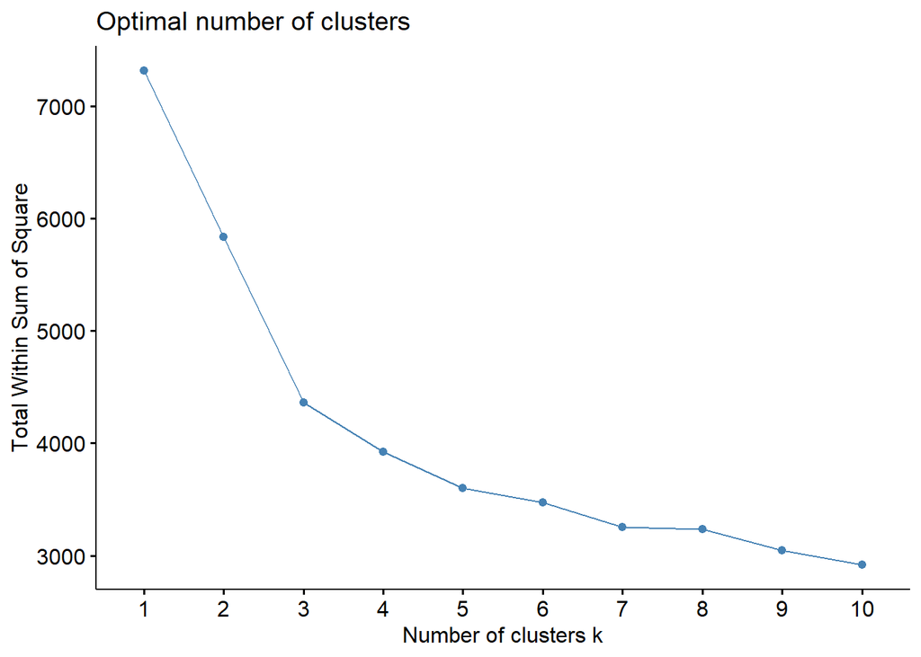

```r
# generate the same random numbers
set.seed(123)
# use the Elbow Method to find the cluster numbers
fviz_nbclust(Rem_Mis_data, kmeans, method = "wss")
```

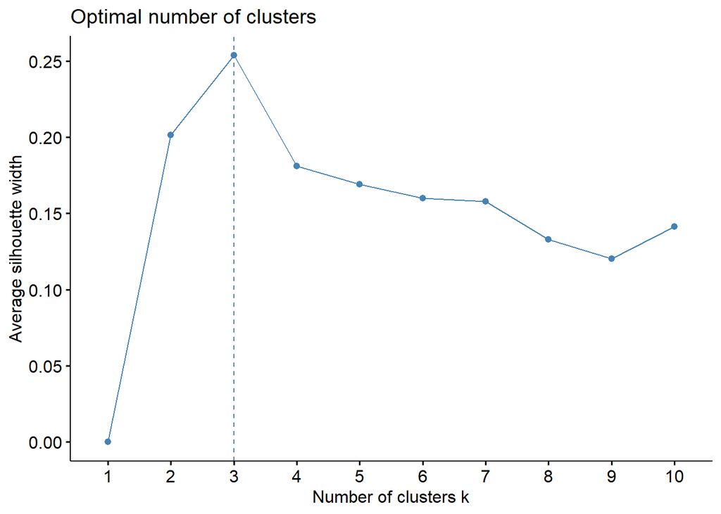

```r
# use the Silhouette Method to find the cluster numbers
fviz_nbclust(Rem_Mis_data, kmeans, method = "silhouette")
```

```r
# choose the cluster number k value = 3 and use kmeans to make the clusters
k3 <- kmeans(Rem_Mis_data, centers = 3, nstart = 25) # iteration counts is 25
# Centroids
k3$centers
```

```
##   X..appli..rec.d X..appl..accepted X..new.stud..enrolled
## 1       2.3905697        2.56587741             2.5326119
## 2      -0.2974318       -0.29626363            -0.3215895
## 3       0.1656253        0.02665701            -0.1796647
##   X..new.stud..from.top.10. X..new.stud..from.top.25. X..FT.undergrad
## 1                 0.2624575                 0.4059173       2.5633440
## 2                -0.3910478                -0.3573682      -0.3278163
## 3                 1.0473856                 1.0364907      -0.2743664
##   X..PT.undergrad in.state.tuition out.of.state.tuition       room      board
## 1       1.4466178       -0.8009155           -0.1971571 -0.2791611 -0.0574326
## 2      -0.2732909       -0.1293629           -0.2311175 -0.4534200 -0.2094851
## 3      -0.4773773        1.3790073            1.4729401  0.1196992  0.6969544
##     add..fees estim..book.costs estim..personal.. X..fac..w.PHD
## 1  0.34784232        0.15240247       0.787711624     0.8955099
## 2 -0.06683581       -0.06037046      -0.006399304    -0.2421210
## 3 -0.07107609        0.04230999      -0.573668320     0.9810908
##   stud..fac..ratio Graduation.rate
## 1       0.28878469      0.02918124
## 2       0.01738081     -0.13155901
## 3      -0.66753932      1.09775850
```

```r
# size of each cluster
k3$size
```

```
## [1]  46 276 149
```

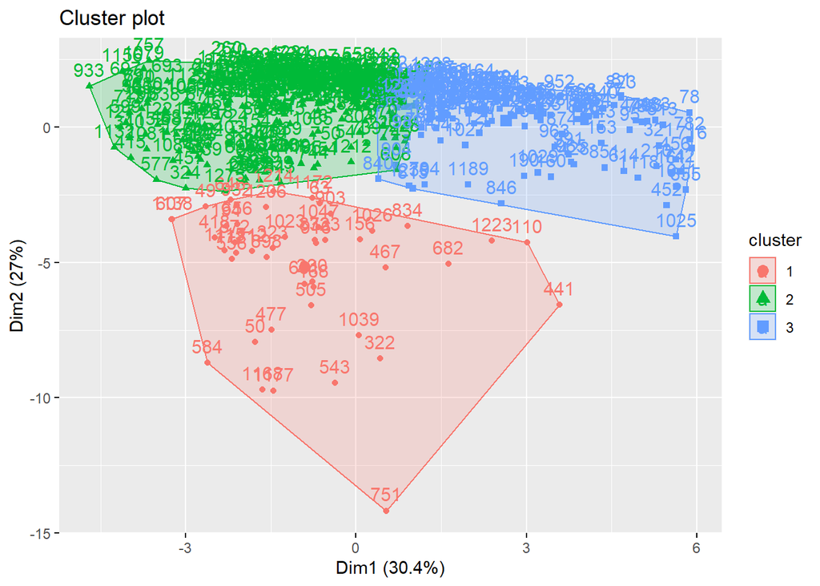

```r
# Visualize the 3 clusters
fviz_cluster(k3, data = Rem_Mis_data)
```

### Compare summary statistics for each cluster

We cannot describe the centroids data by our eyes since there are 17 continuous variables. I plan to do a plot to make the data visualized obviously.

I use the pivot_longer to make the y variables not too redundant because of the 17 continuous measurements.

```r
# name the centroids
centroid_vari <- k3$centers
# transfer centroids to data frame
centroid_vari <- as.data.frame(centroid_vari)
# add cluster to the centroids data frame
centroid_vari$cluster <- c(1,2,3)
# preview the new centroids
centroid_vari
```

```
##   X..appli..rec.d X..appl..accepted X..new.stud..enrolled
## 1       2.3905697        2.56587741             2.5326119
## 2      -0.2974318       -0.29626363            -0.3215895
## 3       0.1656253        0.02665701            -0.1796647
##   X..new.stud..from.top.10. X..new.stud..from.top.25. X..FT.undergrad
## 1                 0.2624575                 0.4059173       2.5633440
## 2                -0.3910478                -0.3573682      -0.3278163
## 3                 1.0473856                 1.0364907      -0.2743664
##   X..PT.undergrad in.state.tuition out.of.state.tuition       room      board
## 1       1.4466178       -0.8009155           -0.1971571 -0.2791611 -0.0574326
## 2      -0.2732909       -0.1293629           -0.2311175 -0.4534200 -0.2094851
## 3      -0.4773773        1.3790073            1.4729401  0.1196992  0.6969544
##     add..fees estim..book.costs estim..personal.. X..fac..w.PHD
## 1  0.34784232        0.15240247       0.787711624     0.8955099
## 2 -0.06683581       -0.06037046      -0.006399304    -0.2421210
## 3 -0.07107609        0.04230999      -0.573668320     0.9810908
##   stud..fac..ratio Graduation.rate cluster
## 1       0.28878469      0.02918124       1
## 2       0.01738081     -0.13155901       2
## 3      -0.66753932      1.09775850       3
```

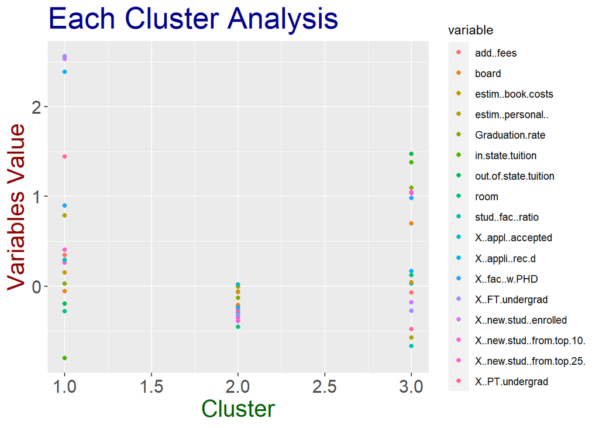

```r
# use the pivot_longer to make 17 variables together
centroid_vari_plot <- centroid_vari %>% select(cluster, X..appli..rec.d, X..appl..accepted, X..new.stud..enrolled, X..new.stud..from.top.10., X..new.stud..from.top.25., X..FT.undergrad, X..PT.undergrad, in.state.tuition, out.of.state.tuition, room, board, add..fees, estim..book.costs, estim..personal.., X..fac..w.PHD, stud..fac..ratio, Graduation.rate) %>% pivot_longer(-cluster, names_to = "variable", values_to = "value")
# use ggplot to plot the picture
t <- ggplot(centroid_vari_plot, aes(cluster, value, colour = variable)) + geom_point()
t + xlab("Cluster") +    # name x axis
    ylab("Variables Value") +   # name y axis
    ggtitle("Each Cluster Analysis") +   # name the figure title
    theme(axis.title.x = element_text(color="DarkGreen", size=20), # change x axis name's color and size
          axis.title.y = element_text(color="Darkred", size=20),   # change y axis name's color and size
          axis.text.x = element_text(size=15),   # change x axis number's size
          axis.text.y = element_text(size=15),   # change y axis number's size
          plot.title = element_text(color="DarkBlue", size=25))   # change title's color and size
```

We can see from the figure above :

Cluster 1 is the Universities with low tuition fee, high number of students enrolled and low number of rooms.

Cluster 2 variables are really close to each other and cannot tell the difference.

Cluster 3 is the Universities with high tuition fee, low number of students enrolled and high number of rooms.

### K means clustering for categorical measurements

We use 2 categorical measurements(State and Private/Public) to characterize the different clusters.

I do the histogram plot use the ggplot to make the outcome obviously.

```r
# Remove the missing data from the variable above
data.norm.with.category.Rem <- data_norm_with_category[complete.cases(data_norm_with_category),]
# combine with cluster into the data
data_total_cluster <- cbind(data.norm.with.category.Rem, cluster = k3$cluster)
# preview the data
head(data_total_cluster, 3)
```

```
##                      College.Name State Public..1...Private..2. X..appli..rec.d
## 1       Alaska Pacific University    AK                       2      -0.7225059
## 3  University of Alaska Southeast    AK                       1      -0.7357753
## 10    Birmingham-Southern College    AL                       2      -0.5497209
##    X..appl..accepted X..new.stud..enrolled X..new.stud..from.top.10.
## 1         -0.7662308            -0.8183340                -0.5281592
## 3         -0.7791147            -0.7798976                -1.1834451
## 10        -0.5698620            -0.5560621                 2.2568059
##    X..new.stud..from.top.25. X..FT.undergrad X..PT.undergrad in.state.tuition
## 1                  -0.399879      -0.7577075      -0.1270939       -0.0630636
## 3                  -1.357673      -0.7042403       0.4589594       -1.1509138
## 10                  1.707268      -0.5097344      -0.5229789        0.7035548
##    out.of.state.tuition         room     board  add..fees estim..book.costs
## 1            -0.4116519 -0.777418588 0.6634249 -0.5582110         1.4939890
## 3            -0.9712607 -0.000592575 0.2856342 -0.7627364        -0.2986034
## 10            0.5713798 -0.403777441 0.5576435 -0.5795157        -0.8961342
##    estim..personal.. X..fac..w.PHD stud..fac..ratio Graduation.rate cluster
## 1          0.1549998     0.4125706       -0.5704863      -2.4037893       2
## 3         -0.3182253    -1.6630926       -1.0332351      -1.1332124       2
## 10        -0.6850447     0.3003726       -0.1655810       0.6138307       3
```

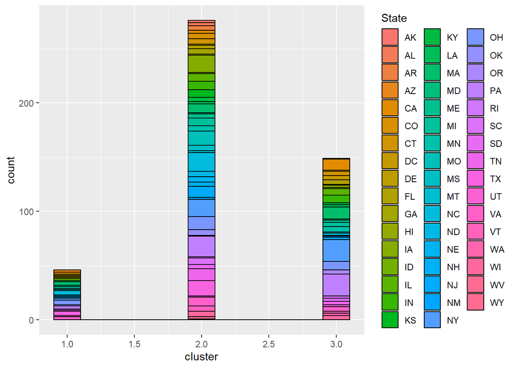

```r
# plot the categorical measurements with clusters
p <- ggplot(data = data_total_cluster, aes(x = cluster))
# plot State
p + geom_histogram(binwidth = 0.2, aes(fill = State), color = "Black")
```

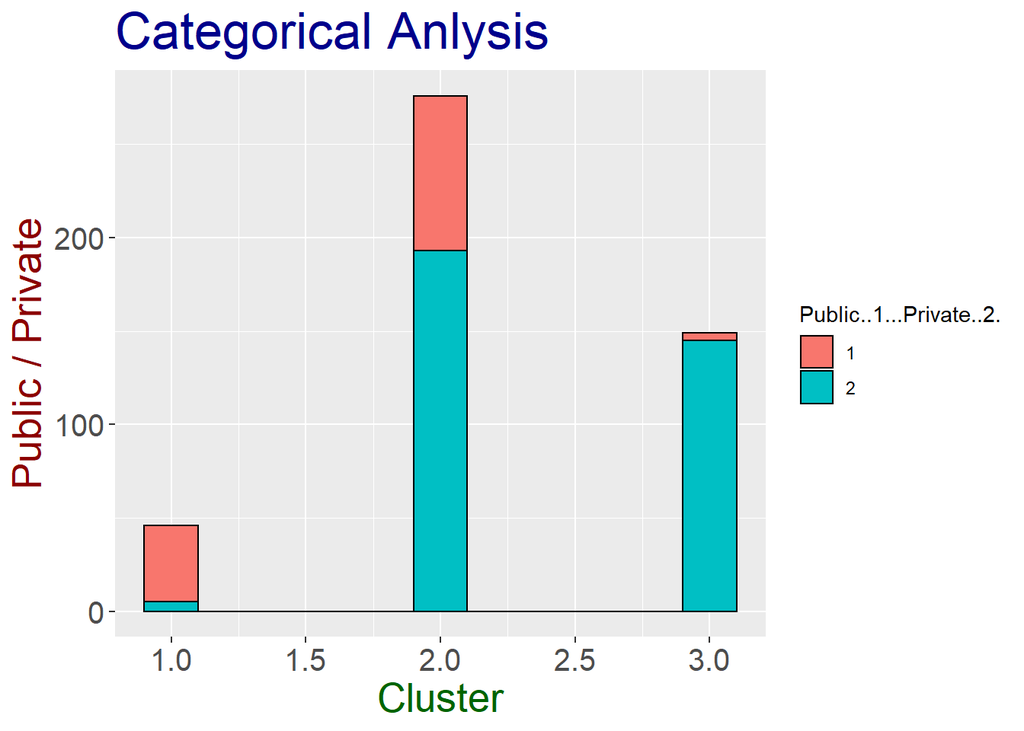

```r
# plot Public/Private
h <- p + geom_histogram(binwidth = 0.2, aes(fill = Public..1...Private..2.), color = "Black")
h + xlab("Cluster") +     # name x axis
    ylab("Public / Private") +   # name y axis
    ggtitle("Categorical Anlysis") +    # name the figure title
    theme(axis.title.x = element_text(color="DarkGreen", size=20),  # change x axis name's color and size
          axis.title.y = element_text(color="Darkred", size=20),    # change y axis name's color and size
          axis.text.x = element_text(size=15),    # change x axis number's size
          axis.text.y = element_text(size=15),    # change y axis number's size
          plot.title = element_text(color="DarkBlue", size=25))     # change title's color and size
```

I plot the 2 categorical measurements with 3 clusters. The State figure is meaningless because they are all mixed together.

The Public/Private school is absolutely meaningful from the picture :

Cluster 1 is mainly for the Public Universities.

Cluster 2 is the mix of Public and Private Universities.

Cluster 3 is mainly for the Private Universities.

### External Infomation

As we can see from the Public/Private ~ Cluster figure above, it is not fair to judge a university from they are Private or Public. Although Cluster 1 & 3 are typically Public Universities and Private Universities, respectively, Cluster 2 is the mixed which means the Private Universities in this part can also have relatively lower tuition fee and higher students enrolled. Vise verse, the Public Universities in Cluster 2 can also have higher tuition fee and low students enrolled.

Besides, the size of each cluster is 46, 276 ans 149. Cluster 2 which is the mixed one of Public and Private, the size of cluster 2 is even larger than the sum of the others. We can see the number of the “mixed standard” universities is not small.

### Tufts University

Compute the Euclidean distance from Tufts University to each 3 clusters.

Tufts University’s X..PT.undergrad is missing.

```r
# choose Tufts University's row
Tufts_Uni <- data_norm_with_category[which(data_norm_with_category$College.Name == "Tufts University"),]
# check the missing variable
Tufts_Uni
```

```
##         College.Name State Public..1...Private..2. X..appli..rec.d
## 476 Tufts University    MA                       2        1.372653
##     X..appl..accepted X..new.stud..enrolled X..new.stud..from.top.10.
## 476         0.7705108             0.4817205                  1.874556
##     X..new.stud..from.top.25. X..FT.undergrad X..PT.undergrad in.state.tuition
## 476                  1.803047       0.1992003              NA         2.207062
##     out.of.state.tuition      room    board add..fees estim..book.costs
## 476             2.499321 0.4547283 1.313225 0.2364556         0.2989274
##     estim..personal.. X..fac..w.PHD stud..fac..ratio Graduation.rate
## 476        -0.6458426      1.702848       -0.8789855        1.672645
```

```r
# exclude the cluster column in centroids data
centroid_exclu_cluster <- centroid_vari[,-18]
# split each cluster variables in centroids data and exclude the missing value in Tufts University
cluster1 <- centroid_exclu_cluster[1,-7] # 7 is the index for X..PT.undergrad
cluster2 <- centroid_exclu_cluster[2,-7]
cluster3 <- centroid_exclu_cluster[3,-7]
# Remove the categorical measurements and missing variable in Tufts University
Tufts_Uni_rem <- Tufts_Uni[,-c(1:3,10)]
# Calculate the Euclidean Distance from Tufts University to each cluster
cluster1_Tufts <- get_dist(rbind(cluster1, Tufts_Uni_rem), method = "euclidean")
cluster2_Tufts <- get_dist(rbind(cluster2, Tufts_Uni_rem), method = "euclidean")
cluster3_Tufts <- get_dist(rbind(cluster3, Tufts_Uni_rem), method = "euclidean")
# show the distance differences results
cluster1_Tufts
```

```
##            1
## 476 6.644342
```

```r
cluster2_Tufts
```

```
##            2
## 476 6.259365
```

```r
cluster3_Tufts
```

```
##           3
## 476 2.69011
```

```r
# the closest distance
min(cluster1_Tufts, cluster2_Tufts, cluster3_Tufts)
```

```
## [1] 2.69011
```

```r
# choose College.Name & X..PT.undergrad from the raw data not normalized
x <- data[complete.cases(data),] %>% select(College.Name, X..PT.undergrad)
# combine the specific data with different clusters
y <- cbind(x, cluster = data_total_cluster$cluster)
# choose the Tufts University's cluster which is Cluster 3
z <- y %>% filter(cluster == 3)
# calculate the average X..PT.undergrad number from Cluster 3
round(mean(z$X..PT.undergrad))
```

```
## [1] 283
```

```r
# Replace the missing data with the average number
data[data$College.Name == "Tufts University", "X..PT.undergrad"] <- round(mean(z$X..PT.undergrad))
# Check the replace statement
data %>% filter(College.Name == "Tufts University",)
```

```
##       College.Name State Public..1...Private..2. X..appli..rec.d
## 1 Tufts University    MA                       2            7614
##   X..appl..accepted X..new.stud..enrolled X..new.stud..from.top.10.
## 1              3605                  1205                        60
##   X..new.stud..from.top.25. X..FT.undergrad X..PT.undergrad in.state.tuition
## 1                        90            4598             283            19701
##   out.of.state.tuition room board add..fees estim..book.costs estim..personal..
## 1                19701 3038  2930       503               600               928
##   X..fac..w.PHD stud..fac..ratio Graduation.rate
## 1            99             10.3              92
```

Tufts University’s distance to Cluster 3 is 2.69 which is the closest distance in the 3 clusters. So Tufts University should belong to the Cluster 3.

After the calculation above, the missing variable which is X..PT.undergrad in Tufts University is 283.

The End